# XGBoost for Image Recognition

# Loss function for Gradient Boosting (Classification)

- One commonly used loss function gradient boosting (classification) is the negative of loglikelihood
- The loss function of gradient boosting is then expressed in terms of log(Odds) as shown:

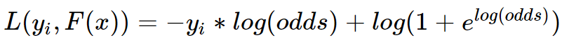

- where yi is the observed value and F(x) is the predicted value

# Big Idea of Gradient Boosting

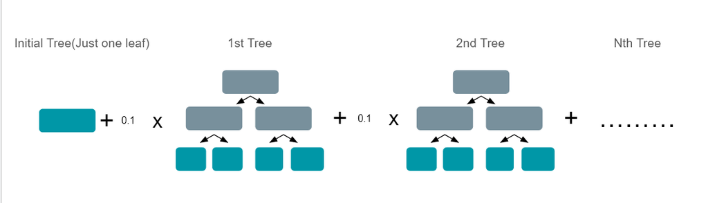

- This diagram represents the outcome of gradient boosting. We start off with just one leaf associated with an initial prediction. We then build more trees to improve on the previous prediction.
- The objective of gradient boosting is to minimize the loss function by looking for optimal $\gamma$ value.
- $\gamma$ is a parameter that potentially improves the $log(odds)$ (and hence the predicted probability) with each iteration.
- Learning rates are the hyper meters which controls how much we are adjusting the weights of our network with respect to the loss gradient. The learning rate affects how quickly our model can converge to a local minima (our best accuracy). In the diagram above, 0.1 is a learning rate.
- The relationship is given by: new_weight = existing_weight - learning_rate * gradient
- We basically update the predictions such that the sum of our residuals is close to zero and the predicted values are close to actual values.

# Gradient Boosted Trees - Diabetes Example

- We will go through step-by-step of how the Gradient Boosting Algorithm is used to predict this Diabetes example. This small example is used to illustrate the big idea. For simplicity, we will only consider binary classification
- We have 3 predictor variables: “BMI”, “Age”, and “Sex”. We have our outcome: “Is diabetic” which is a categorical data. Hence, we will use classification modeling in our Gradient Boosting Algorithm.
- We want to predict whether an individual will have a diabetes based on “BMI”, “Age”, and “Sex”.

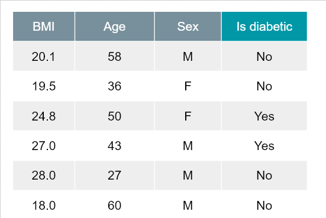

# Gradient Boosted Trees - Diabetes Example

# Gradient Boosted Trees - Diabetes Example

- $Residual = Observed - Predicted$

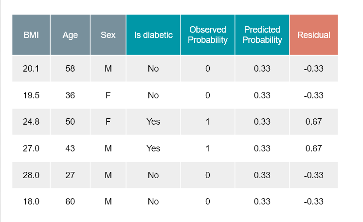

- Using the 3 predictor variables, next we build a tree to predict the residuals. Things will become clearer as we finish one iteration. Please be patient.
- Why predict the residuals?
- Recall: The main idea of boosting is to add new models to the ensemble sequentially. At each particular iteration, a new weak, base-leaner model is trained with respect to the error of the whole ensemble learnt so far.

# Gradient Boosted Trees - Diabetes Example

- From the residual, we can derive such decision tree where there are only 4 leaves. However, in practice, people often set the maximum number of leaves to be between 8 and 32. The residuals are colored coded for easy tracking of where it belongs in the leaves of the tree.

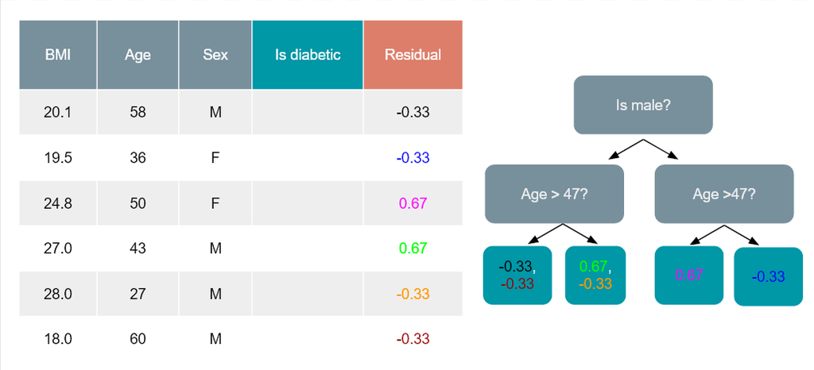

- Next, let’s us calculate the output values for the leaves.

# Gradient Boosted Trees - Diabetes Example

- We will use the transformation function to calculate the output values of the residual leaf:

$$\frac{\sum residual_i}{\sum [Previous\ Prob._i *(1-Previous\ Prob._i)]}$$

- This transformation function is derived by minimizing the loss function by looking for the optimal $\gamma$ (refer to Big Idea slide for more information).
- The derivation of this transformation function can be found in Annex slide.

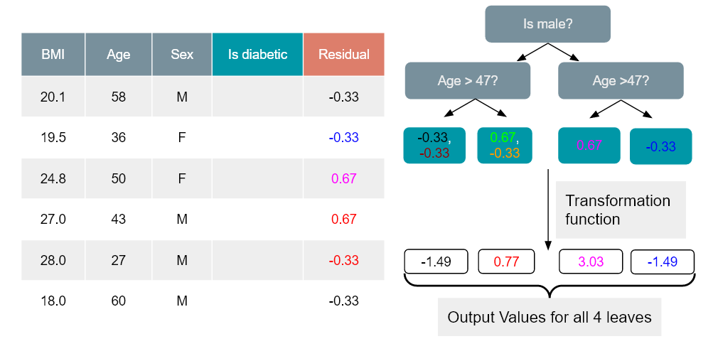

- Now, we are ready to update our predictions by combining the initial leaf with the new tree.

# Gradient Boosted Trees - Diabetes Example

- To do the update, let’s first calculate the $log(odd)\ prediction$ for all individuals or observations
- Let’s consider a female age 36 as an example: $log(odds)\ Prediction = -0.69+0.1*(-1.49)=-0.84$ where $0.1$ is the learning rate (refer to Big Idea slide)
- This is equivalent to $Probability = \frac{e^{-0.84}}{1+e^{-0.84}}=0.30$

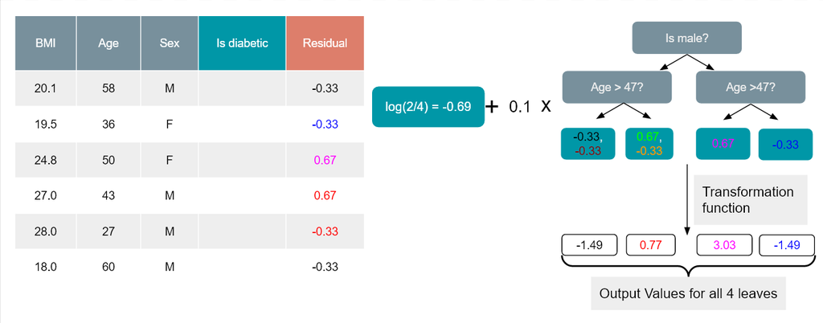

# Gradient Boosted Trees - Diabetes Example

- Now, we have a completed list of new predicted probability.

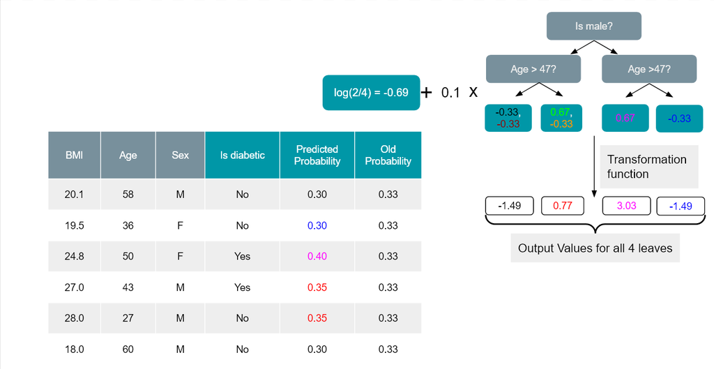

# Gradient Boosted Trees - Diabetes Example

- Now, we can compute the new residual based on the new predicted probability.

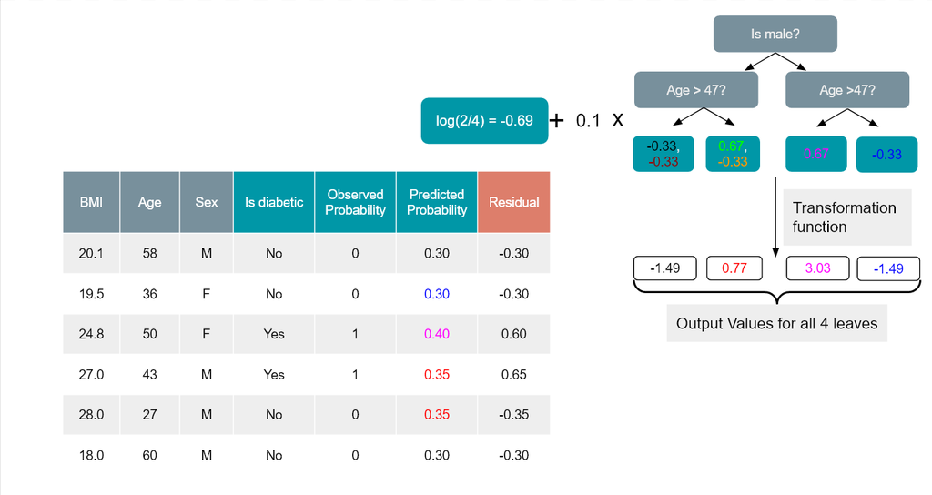

- Once we have the residual, the new cycle begins again.
- We also see that after one iteration, the predicted probability of (Female, 36) is decreased from original prediction of 0.33 to 0.30. Thus, we are taking a small step in the right direction.

# Gradient Boosted Trees - Diabetes Example

- To summarize, we started with just a leaf, which made one prediction for every individual.
- Then we build a tree based on the residuals. Then we calculated output values for each leave and we scale it with a learning rate. Then we built another tree based on the new residuals. Then we calculated the output values for each leave and we scale it with the same learning rate as well.
- This process repeats till we have made the maximum number of trees specified, or the residuals get super small.

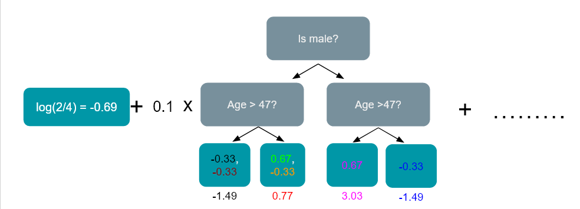

- So this is how gradient boosted tree work in our small diabetes example. In the next slide, we will take a look at how gradient boosting is similar to gradient descent idea.

# Link: Gradient Descent

- In Gradient descent, it can be succinctly written as: $p_{n+1}=p_n-\eta\nabla f(p_n)$ where $\eta$ is the learning rate
- Gradient Descent Algorithm iteratively calculates the next point using gradient at the current position, then scales it (by a learning rate) and subtracts obtained value from the current position (makes a step). It subtracts the value because we want to minimise the function (to maximise it would be adding) (Robert Kwiatkowski, 2021)

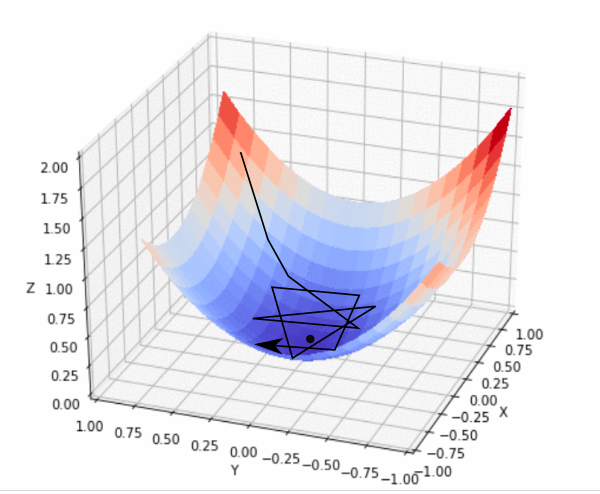

- In Gradient Boosting, we are finding a $\gamma$ value that minimizes the loss function. In the diagram below, we want to find the position of the purple ball that gives the smallest loss function value.

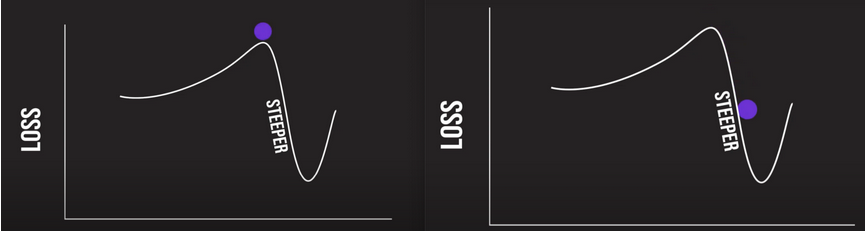

- Now, let’s move on to the scary part: Mathematics behind Gradient Boosted Trees.

# Gradient Boosted Trees - Math Explained

- Input: Data ${(x_i,y_i)^n_{i=1}}$ , and a differentiable Loss Function $L(y_i,F(x))$
- Step 1: Initialize model with a constant value: $F_0(x) =\displaystyle argmin_{\gamma} \sum_{i=1}^{n} L(y_i,\gamma)$
- Step 2: for m =1 to M:
  - 1. Compute $r_{im}=-[\frac{\partial L(y_i, F(x_i)}{\partial F(x_i)}]_{F(x)=F_{m-1}(x)}$ for $i=1,...,n$
  - 2. Fit a regression tree to the $r_{im}$ values and creates terminal regions $R_{im},$ for $j=1,...,J_m$
  - 3. For $j=1...J_m$ compute $\gamma_{jm}=\displaystyle argmin_{\gamma} \sum_{x_i\in R_{ij}} L(y_i,F_{m-1}(x_i)+\gamma)$
  - 4. Update $F_m(x)=F_{m-1}(x)+v \sum_{j=1}^{J_m} \gamma_mI(x\in R_{jm})$
- Step 3: Output $F_M(x)$

# Gradient Boosted Trees - Input

- *Input: Data* ${(x_i,y_i)^n_{i=1}}$ *, and a differentiable Loss Function* $L(y_i,F(x))$

  ……………………………………………………………………………………………………………………………………..
- ${(x_i,y_i)^n_{i=1}}$ represents data points where $x_i$ is the row of features and $y_i$ is the label or observed value.
- $L(y_i,F(x))=-y_i *log(odds)+log(1+e^{log(odds)})$ represents the loss function between our observed value $y_i$and the predicted value $F(x)$ or $log(odds)$.
- The loss function value is high when the label and prediction do not agree, and the loss function value is zero when they are in perfect agreement.

# Gradient Boosted Trees - Step 1

- *Input: Data* ${(x_i,y_i)^n_{i=1}}$ *, and a differentiable Loss Function* $L(y_i,F(x))$
- *Step 1: Initialize model with a constant value:* $F_0(x) =\displaystyle argmin_{\gamma} \sum_{i=1}^{n} L(y_i,\gamma)$

  ……………………………………………………………………………………………………………………………………..
- This step is to find a optimal value of $\gamma$ that minimizes the loss function $L(y_i,\gamma)$ where observed value $y_i$ and predicted value $\gamma$ or $log(odds)$
- Since $L(y_i,F(x))=-y_i *log(odds)+log(1+e^{log(odds)})$, we have: $\frac{\partial L}{\partial F(x)}=-y_i+\frac{e^{log(odds)}}{1+e^{log(odds)}}=-y_i+p$
- Equate $\frac{\partial L}{\partial F(x)}$ to $0$, we get $F_0(x) =log(odds)=log(\frac{p}{1-p})$. Note: This is our initial prediction which corresponds to $log(\frac{2}{4})$ in the diabetes example.

# Gradient Boosted Trees - Step 2 - (A)

- *Step 2: for m =1 to M:*
  - 1. *Compute* $r_{im}=-[\frac{\partial L(y_i, F(x_i)}{\partial F(x_i)}]_{F(x)=F_{m-1}(x)}$ *for* $i=1,...,n$

  ……………………………………………………………………………………………………………………………………..
- In this step, we are essentially calculating the Residuals (also seen in the Diabetes example previously)
- $-[\frac{\partial L(y_i, F(x_i)}{\partial F(x_i)}]$ is the derivative of the loss function with respect to $F(x_i)$ or $log(odds)$.

  $$-[\frac{\partial L(y_i, F(x_i)}{\partial F(x_i)}]=y_i-\frac{e^{log(odds)}}{1+e^{log(odds)}}=y_i-p\\=observed-predicted\\=residual$$
- ${F(x)=F_{m-1}(x)}$ means that we will plug in the most recent predicted $log(odds)$
- Thus, $r_{im}$ is the residual for each sample in the dataset for the first tree.

# Gradient Boosted Trees - Step 2 - (B)

- *Step 2: for m =1 to M:*
  - 1. *Compute* $r_{im}=-[\frac{\partial L(y_i, F(x_i)}{\partial F(x_i)}]_{F(x)=F_{m-1}(x)}$ *for* $i=1,...,n$
  - 2. *Fit a regression tree to the* $r_{im}$ *values and creates terminal regions* $R_{im},$ *for* $j=1,...,J_m$

  ……………………………………………………………………………………………………………………………………..
- In this step, we build the regression tree fit to the residuals and create terminal regions $R_{jm}$ or output values (seen in diabetes example) for all the leaves in the tree

# Gradient Boosted Trees - Step 2 - (C)

- *Step 2: for m =1 to M:*
  - 1. *Compute* $r_{im}=-[\frac{\partial L(y_i, F(x_i)}{\partial F(x_i)}]_{F(x)=F_{m-1}(x)}$ *for* $i=1,...,n$
  - 2. *Fit a regression tree to the* $r_{im}$ *values and creates terminal regions* $R_{im},$ *for* $j=1,...,J_m$
  - 3. *For* $j=1...J_m$ *compute* $\gamma_{jm}=\displaystyle argmin_{\gamma} \sum_{x_i\in R_{ij}} L(y_i,F_{m-1}(x_i)+\gamma)$

  ……………………………………………………………………………………………………………………………………..
- For $j=1...J_m$ means that for each leaf in the new tree we compute an output value $\gamma_{jm}$ , where m is our tree
- $\gamma_{jm}=\displaystyle argmin_{\gamma} \sum_{x_i\in R_{ij}} L(y_i,F_{m-1}(x_i)+\gamma)$ means that we are trying to find the value of $\gamma$ that, when added to the most recent predicted $log(odds)$, minimized the Loss Function
- Derivation of $\gamma_{jm}$ can be referred to in Annex (Just for your knowledge)

# Gradient Boosted Trees - Step 2 - (D) and Step 3

- *Step 2: for m =1 to M:*
  - 1. *Compute* $r_{im}=-[\frac{\partial L(y_i, F(x_i)}{\partial F(x_i)}]_{F(x)=F_{m-1}(x)}$ *for* $i=1,...,n$
  - 2. *Fit a regression tree to the* $r_{im}$ *values and creates terminal regions* $R_{im},$ *for* $j=1,...,J_m$
  - 3. *For* $j=1...J_m$ *compute* $\gamma_{jm}=\displaystyle argmin_{\gamma} \sum_{x_i\in R_{ij}} L(y_i,F_{m-1}(x_i)+\gamma)$
  - 4. *Update* $F_m(x)=F_{m-1}(x)+v \sum_{j=1}^{J_m} \gamma_mI(x\in R_{jm})$
- *Step 3: Output* $F_M(x)$

  ……………………………………………………………………………………………………………………………………..
- In this step, we make a new prediction for each sample based on our output value $\gamma_{jm}$ we calculated from the previous step.
- $F_m(x)=F_{m-1}(x)+v \sum_{j=1}^{J_m} \gamma_mI(x\in R_{jm})$ represents a new prediction based on the old prediction $F_{m-1}(x)+ learning\ rate\ v$ and all the output values $\gamma_{jm}$ of all the leaves
- This completes the first iteration and we continue to repeat step 2 (A)-(D) for M number of trees to output the latest prediction $F_m(x)$

# Extreme Gradient Boosting

- Now that we have understood how Gradient Boosting works, Extreme Gradient Boosting is just Gradient Boosting, but with the addition of L1 and/or L2 regularizers.
- Regularization techniques are used to reduce overfitting effects by adding penalty terms in the loss function. For more information on how regularization works, please refer to the lecture on “Model Selection Techniques” in week 5 (slides 48-52).
- In order to shorten the training time of the model, we will instead use XGBoost which is 10 times faster than Gradient Boosted Tree while the underlying principal is still based on Gradient Boosted Tree.

# Code implementation - Dataset Background

- Let’s now try to apply what we learnt into MNIST dataset to predict the handwritten digit.
- MNIST dataset is a large database of handwritten digits that is commonly used fro training various image processing systems. It contains 60,000 training images and 10,000 testing images.
- The set of images in the MNIST database was created in 1998 as a combination of two of NIST’s databases: Special Database 1 and Special Database 3. Special Database 1 and Special Database 3 consist of digits written by high school students and employees of the United States Census Bureau, respectively.
- Next, we will go through step-by-step on the implementation.

# Code Implementation - Steps

1. Import dataset
2. Split & Transform the dataset
3. Train the model
4. Fine-tune the model
5. Predict the model

# Code Implementation - Import Dataset

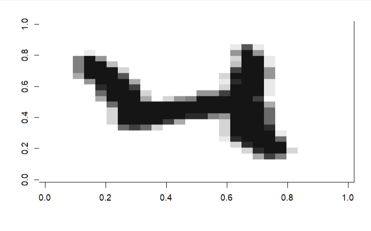

```r
install.packages("devtools")
devtools::install_github("jlmelville/mnist")
library(mnist)
# fetch the data set from the MNIST website
mnist <- download_mnist()
# view the fifth digit
show_digit(mnist, 21)
```

# Code Implementation - Split & Transform the dataset

```r
# first 60,000 instances are the training set
mnist_train <- head(mnist, 60000)
# the remaining 10,000 are the test set
mnist_test <- tail(mnist, 10000)
# Split training and testing set each for features and label
set.seed(1)
label <- mnist_train$Label
numfeatures <- ncol(mnist)
train.data <- as.matrix(mnist_train[,1:numfeatures-1])
train.label <- as.matrix(mnist_train[,numfeatures])
test.data <- as.matrix(mnist_test[,1:numfeatures-1])
test.label <- as.matrix(mnist_test[,numfeatures])
#Next, we transform the training and testing data sets into xgb.DMatrix objects that are used for fitting the XGBoost model and predicting new outcomes.
# Transform the two data sets into xgb.Matrix
xgb.train = xgb.DMatrix(data=train.data,label=train.label)
xgb.test = xgb.DMatrix(data=test.data,label=test.label)
```

# Code Implementation - Train the model

```r
set.seed(123)
num_class = length(levels(label))
params = list(
  booster="gbtree",
  objective="multi:softprob",
  eval_metric="mlogloss",
  num_class=num_class
)
set.seed(123)
xgb.fit=xgb.train(
  params=params,
  data=xgb.train,
  nrounds=5,
  nthreads=2,
  early_stopping_rounds=10,
  watchlist=list(train=xgb.train,test=xgb.test),
  verbose=1
)
xgb.pred = predict(xgb.fit,test.data,reshape=T)
xgb.pred = as.data.frame(xgb.pred)
colnames(xgb.pred) = levels(label)
xgb.pred$prediction = apply(xgb.pred,1,function(x) colnames(xgb.pred)[which.max(x)])
xgb.pred$label = test.label
result = (sum(xgb.pred$prediction==xgb.pred$label)/nrow(xgb.pred))*100
print(paste("The accuracy of this model is", result, "%","."))
```

[output not shown]